# MB5370_Module_01

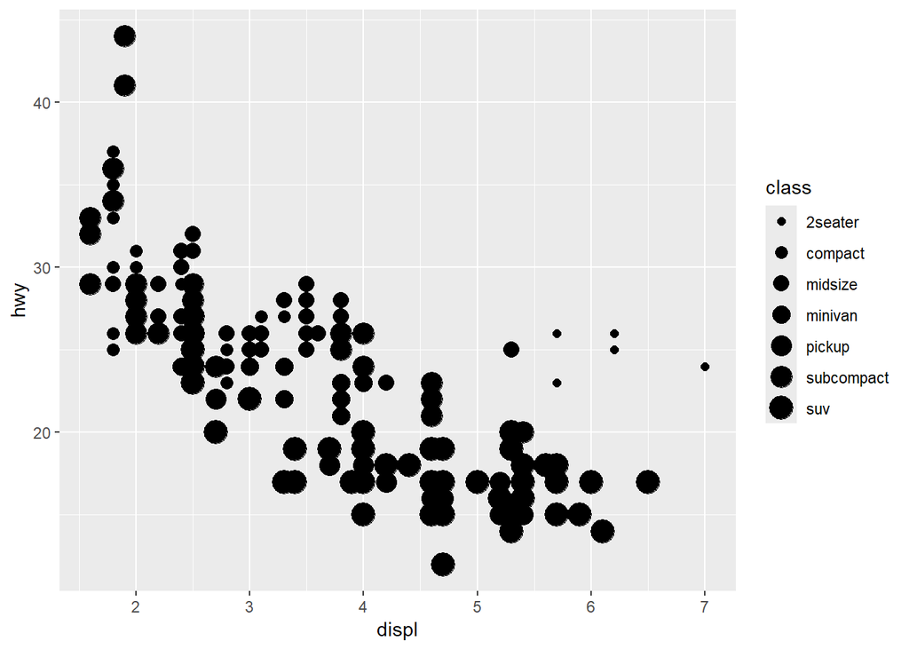

```r
#change point size by class
ggplot(data = mpg) +
  geom_point(mapping = aes(x = displ, y = hwy, size = class))
```

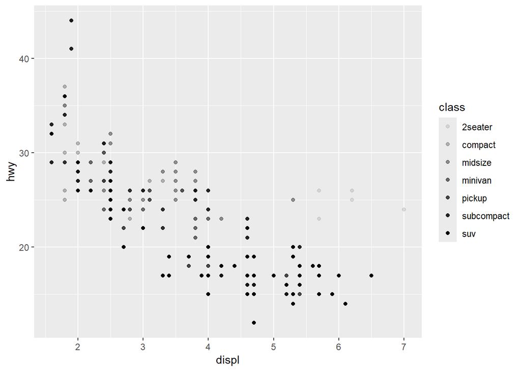

```r
ggplot(data = mpg) +
  geom_point(mapping = aes(x = displ, y = hwy, alpha = class))
```

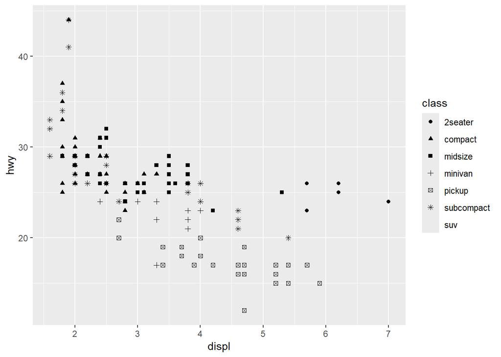

```r
ggplot(data = mpg) +
  geom_point(mapping = aes(x = displ, y = hwy, shape = class))
```

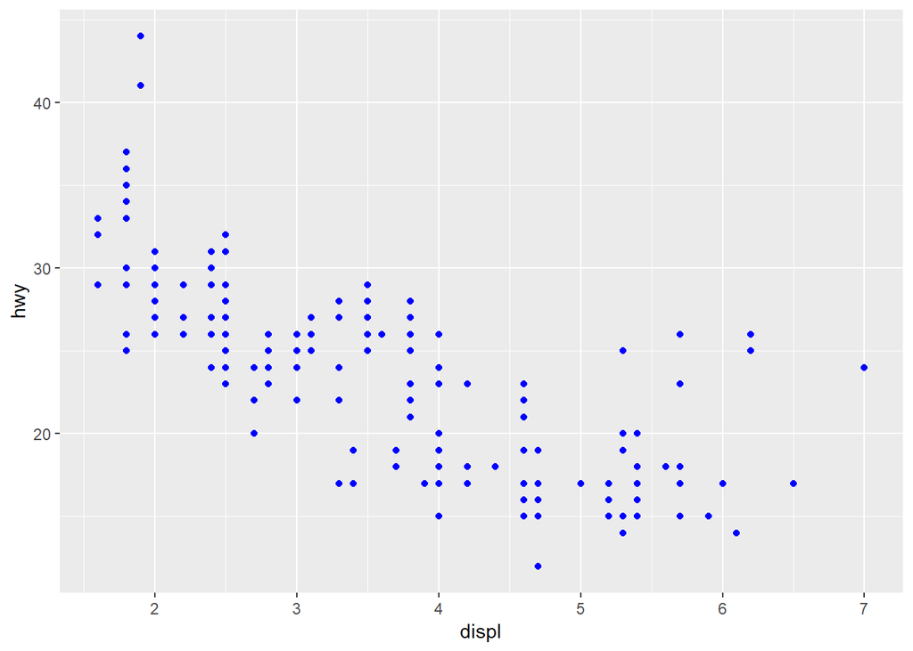

```r
ggplot(data = mpg) +
  geom_point(mapping = aes(x = displ, y = hwy), color = "blue")
```

# Troubleshooting

```r
ggplot(data = mpg) +
  geom_point(mapping = aes(x = displ, y = hwy))
```

[output not shown]

```r
# the + should be on top line
```

# Facet and panel plots

This allows you to break up complex plots to make them more accessible to readers.

Tip: To facet your plot using a single variable, use #facet_wrap(). Facet wrap syntax is in the function of a formula (kind of like a linear model formula), where the ~ dictates which variable you want to subset your data with. Note: only use #facet_wrap() for discrete variables.

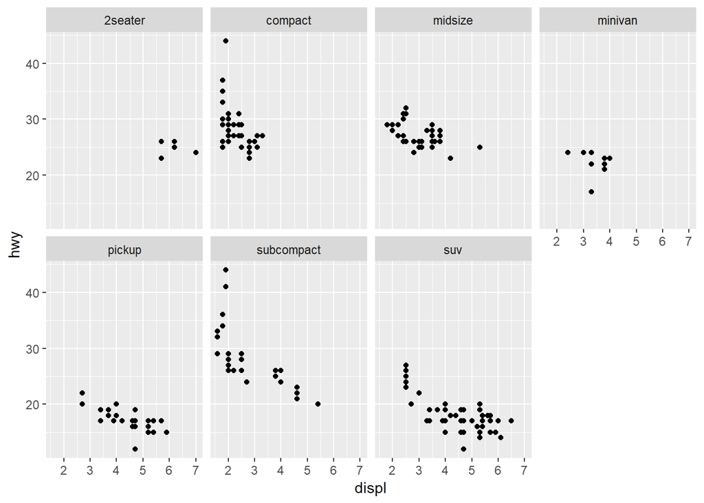

```r
ggplot(data = mpg) +
  geom_point(mapping = aes(x = displ, y = hwy)) +
  facet_wrap(~ class, nrow = 2)
```

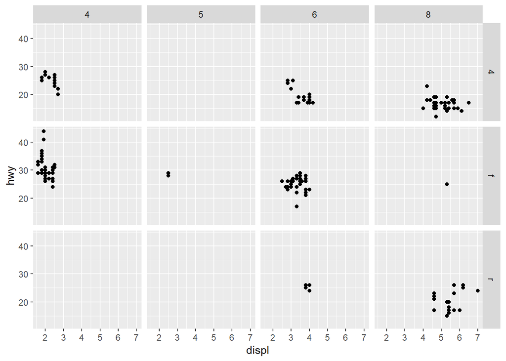

```r
#facet_grip() needs two variables using ~
ggplot(data = mpg) +
  geom_point(mapping = aes(x = displ, y = hwy)) +
  facet_grid(drv ~ cyl)
```

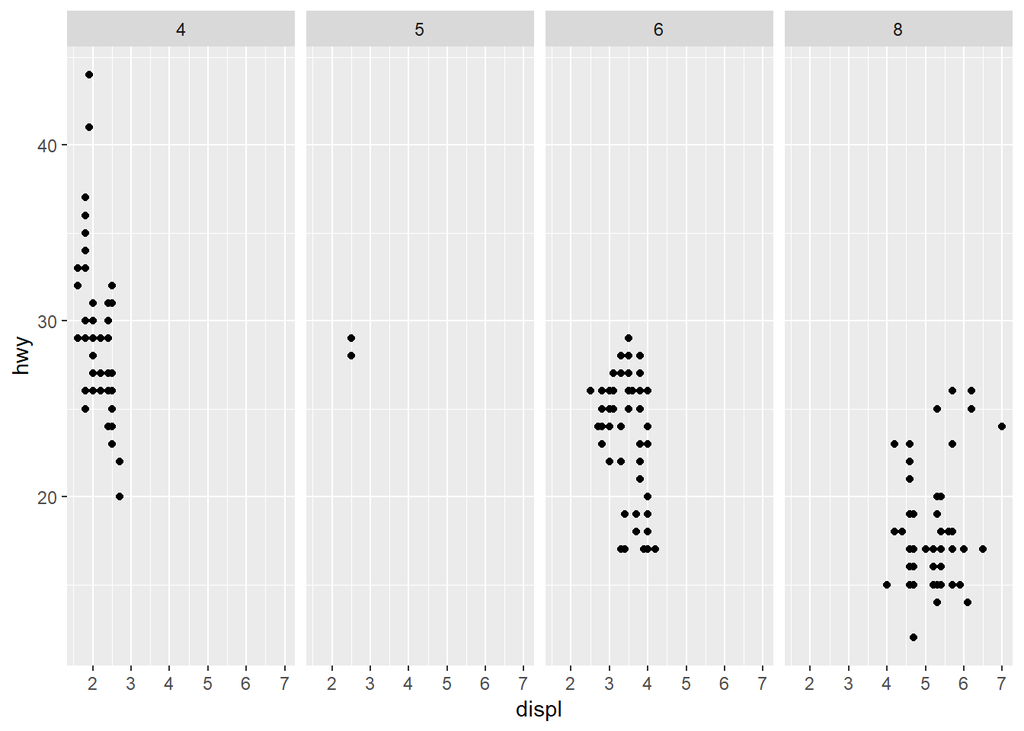

```r
#use . if you don't want to facet in the rows or column dimension
ggplot(data = mpg) +
  geom_point(mapping = aes(x = displ, y = hwy)) +
  facet_grid(.~cyl)
```

## Exercise

```r
#?facet_wrap
```

nrow/ncol represent the number of rows and columns. We can thus control the number of rows and columns we want our data to be presented in. All other options are outlined in ?facet_wrap.

# Fitting simple lines

To display data as points, use geom_point().

```r
#points
ggplot(data = mpg) +
  geom_point(mapping = aes(x = displ, y = hwy))
```

[output not shown]

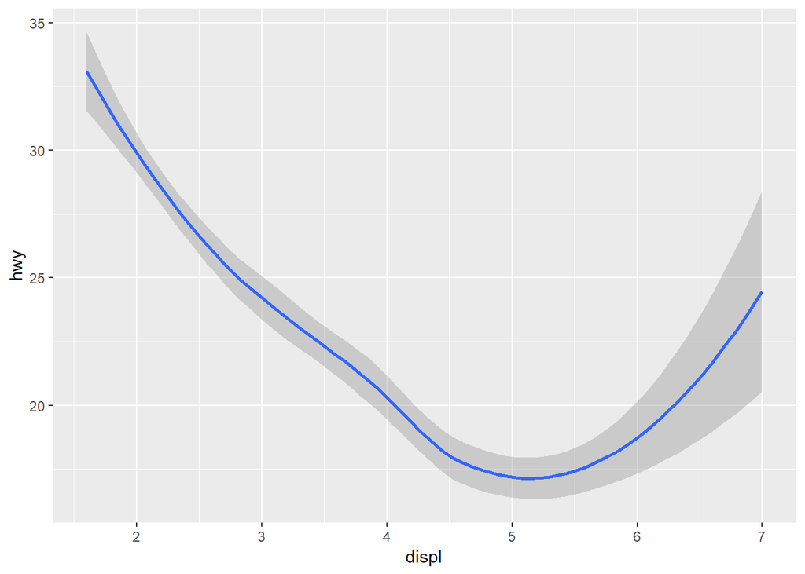

```r
#smooth line
ggplot(data = mpg) +
  geom_smooth(mapping = aes(x = displ, y = hwy))
```

Tip: a #geom is an object that your plot uses to represent the data.

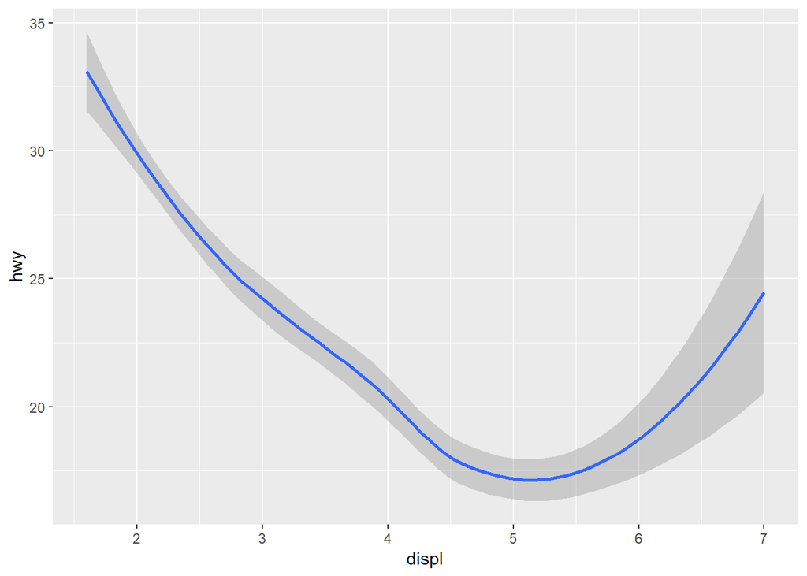

```r
ggplot(data = mpg) +
  #geom_point(mapping = aes(x = displ, y = hwy)) # points horrible
  geom_smooth(mapping = aes(x = displ, y = hwy)) # try smooth line
```

```r
#indeed, the smooth line function is easier to understanding/intepret
```

# Changing line type based on their drv

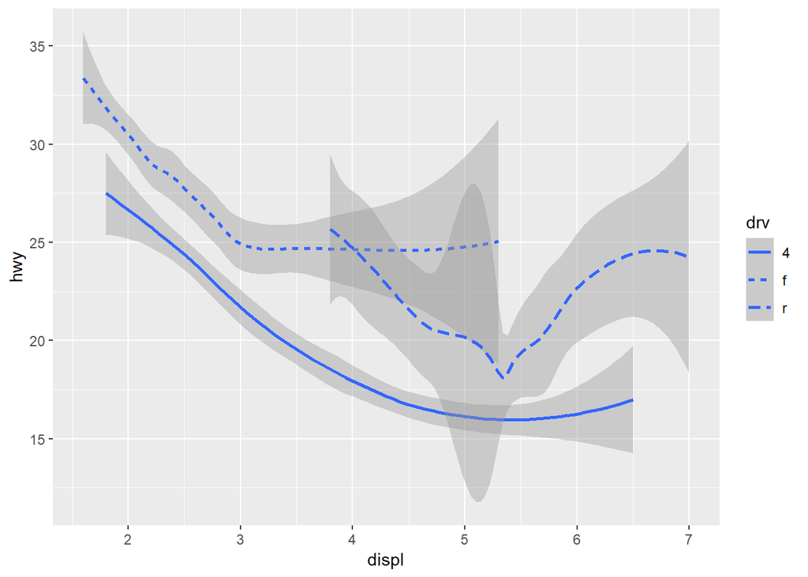

```r
ggplot(data = mpg) +
  geom_smooth(mapping = aes(x = displ, y = hwy, linetype = drv))
```

# Grouping

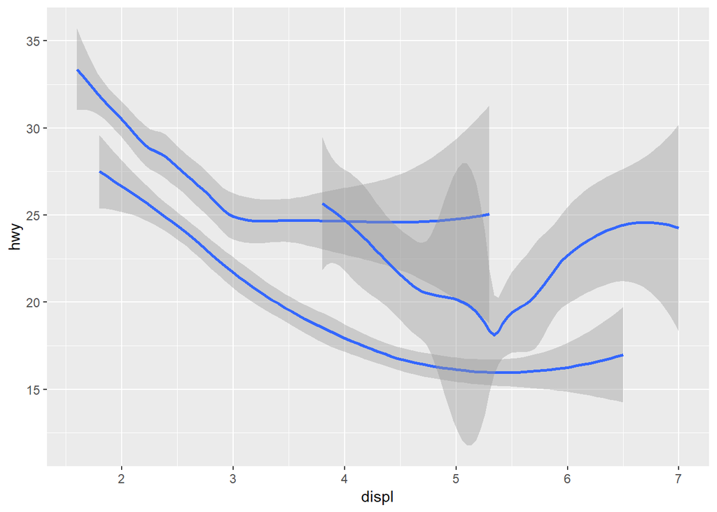

```r
ggplot(data = mpg) +
  geom_smooth(mapping = aes(x = displ, y = hwy, group = drv))
```

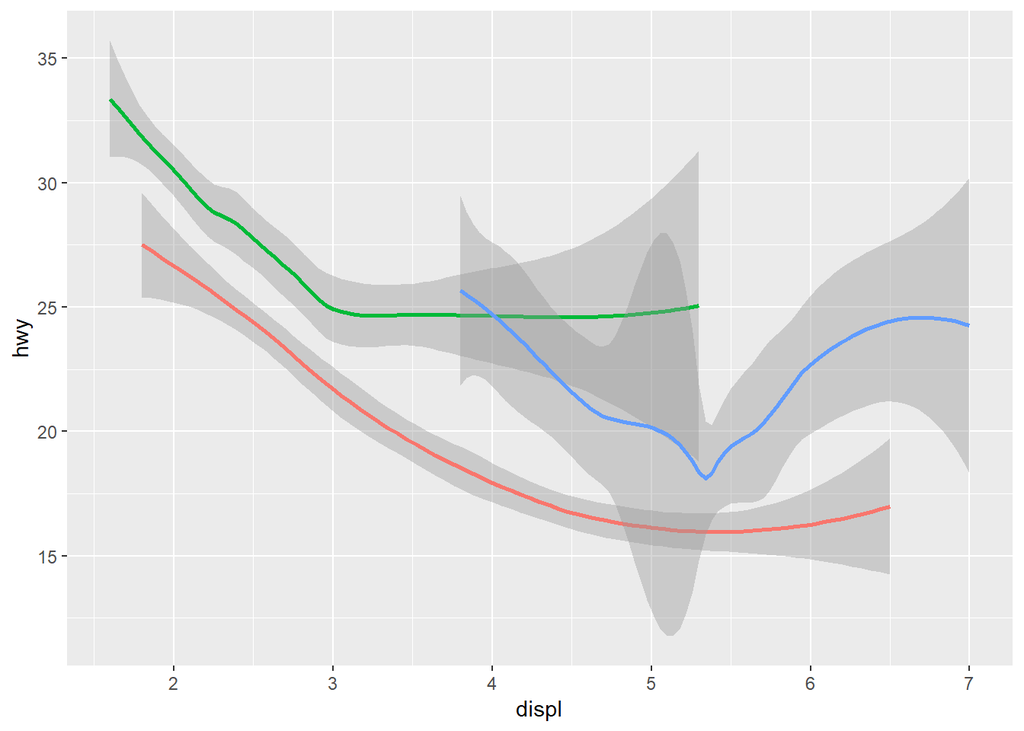

```r
#change line colors
ggplot(data = mpg) +
  geom_smooth(
    mapping = aes(x = displ, y = hwy, color = drv),
    show.legend = FALSE,
  )
```

# Multiple geoms

Using smooth lines and points.

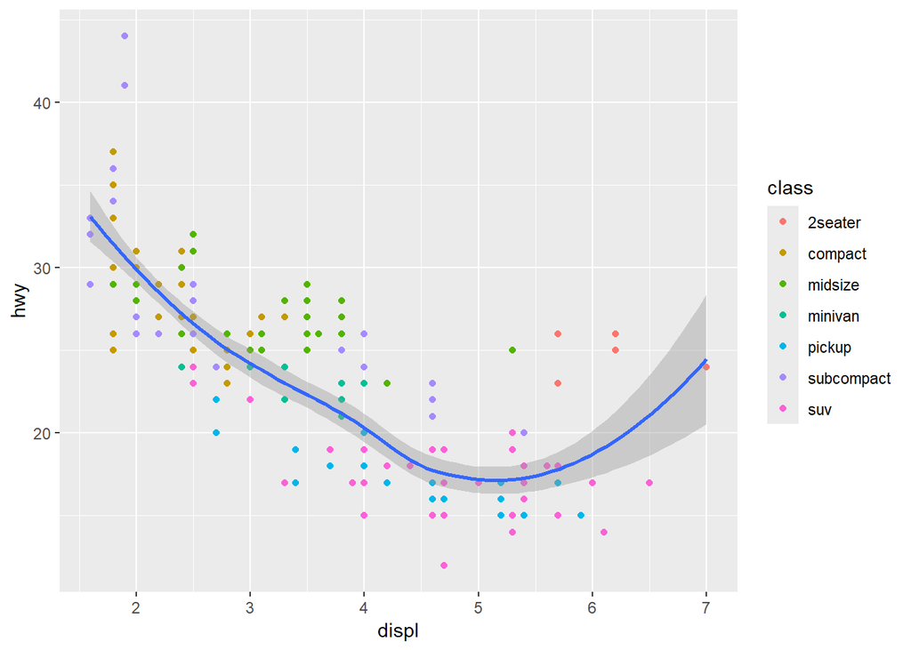

```r
ggplot(data = mpg) +
  geom_point(mapping = aes(x = displ, y = hwy)) + #represents points
  geom_smooth(mapping = aes(x = displ, y = hwy)) #represents line
#in a more effective way
ggplot(data = mpg, mapping = aes(x = displ, y = hwy)) +
  geom_point() +
  geom_smooth()
#mappings
ggplot(data = mpg, mapping = aes(x = displ, y = hwy)) +
  geom_point(mapping = aes(color = class)) +
  geom_smooth()
```

[output not shown]

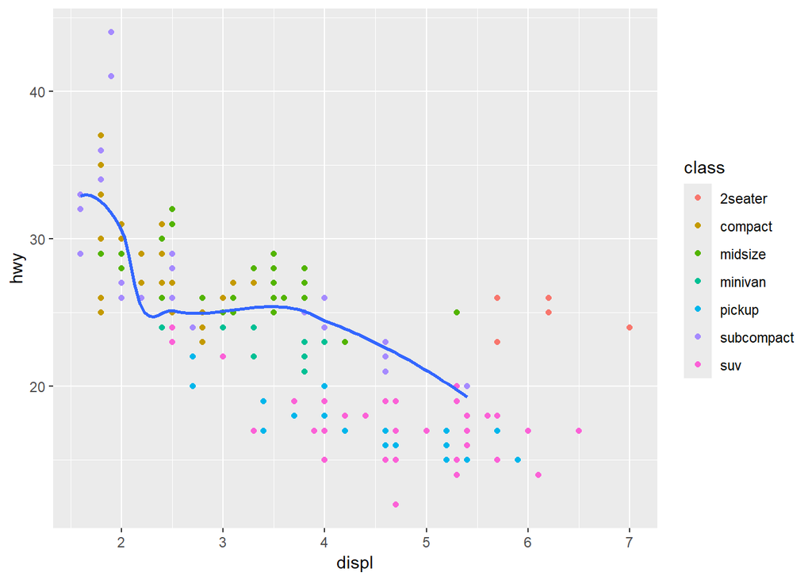

```r
#Specifying different data for each layer, this plots only a subset of our data
ggplot(data = mpg, mapping = aes(x = displ, y = hwy)) +
  geom_point(mapping = aes(color = class)) +
  geom_smooth(data = filter(mpg, class == "subcompact"), se = FALSE)
```

## Exercise

line chart -> geom_line() boxplot -> geom_boxplot() histogram -> geom_histogram() area chart -> geom_area()

```r
#those two plots will look the same. One code is only simpler than the other and avoids repetition.
ggplot(data = mpg, mapping = aes(x = displ, y = hwy)) +
  geom_point() +
  geom_smooth()
ggplot() +
  geom_point(data = mpg, mapping = aes(x = displ, y = hwy)) +
  geom_smooth(data = mpg, mapping = aes(x = displ, y = hwy))
```

[output not shown]

# Tranformations and stats

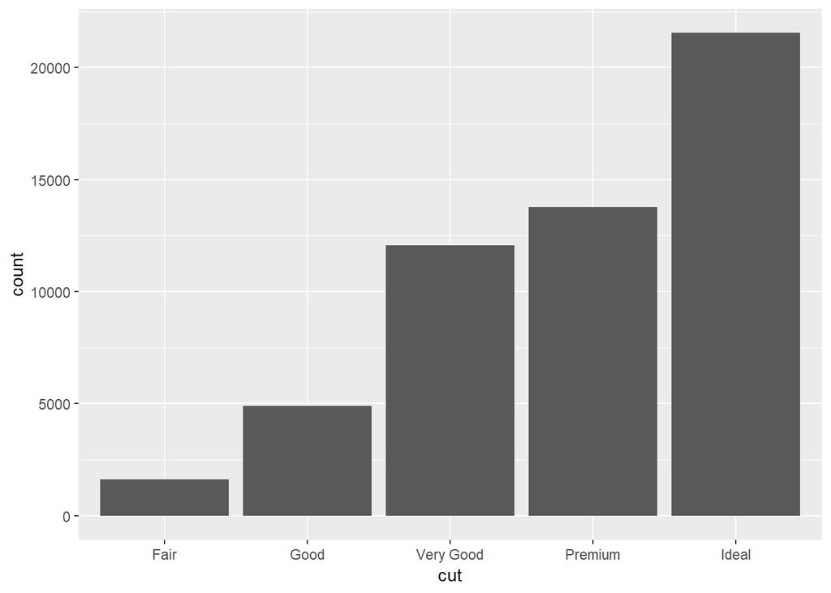

```r
#plotting statistics
ggplot(data = diamonds) +
  geom_bar(mapping = aes(x = cut))
```

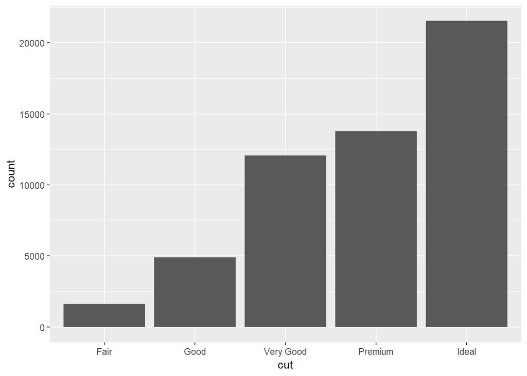

```r
#stat_count() and geom_bar() can be used interchangeably
ggplot(data = diamonds) +
  stat_count(mapping = aes(x = cut))
```

# Override default

```r
demo <- tribble(
  ~cut,         ~freq,
  "Fair",       1610,
  "Good",       4906,
  "Very Good",  12082,
  "Premium",    13791,
  "Ideal",      21551
)
demo
```

```
## # A tibble: 5 × 2
##   cut        freq
##   <chr>     <dbl>
## 1 Fair       1610
## 2 Good       4906
## 3 Very Good 12082
## 4 Premium   13791
## 5 Ideal     21551
```

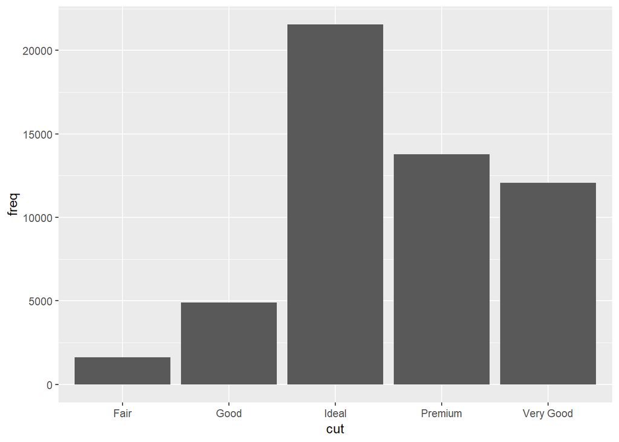

```r
ggplot(data = demo) +
  geom_bar(mapping = aes(x = cut, y = freq), stat = "identity")
```

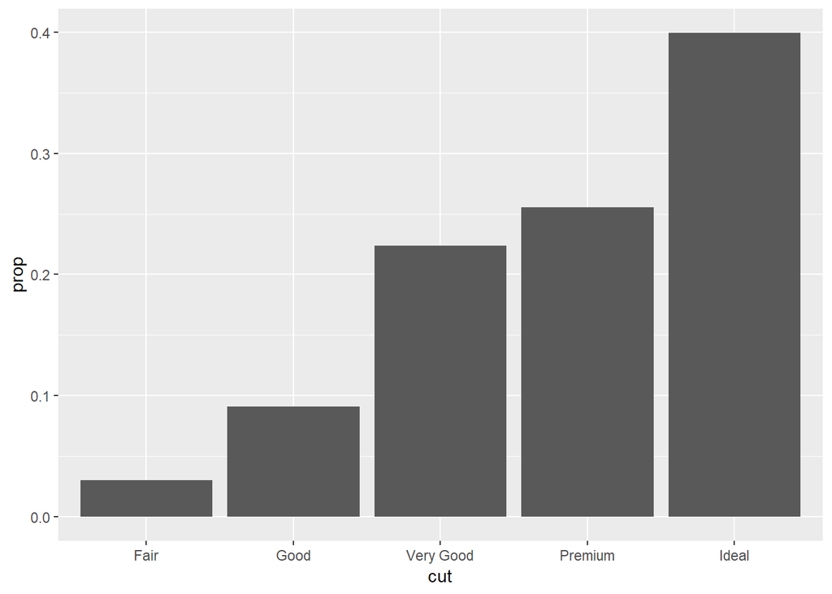

```r
#override a default mapping from transformed variables to aes
ggplot(data = diamonds) +
  geom_bar(mapping = aes(x = cut, y = stat(prop), group = 1))
```

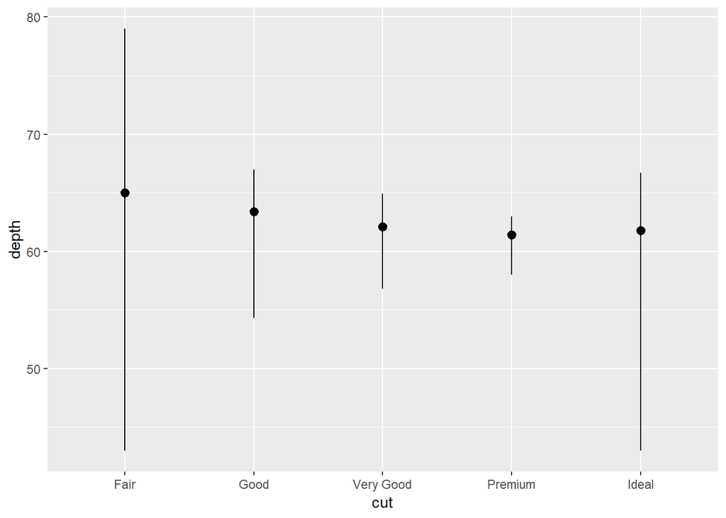

```r
#plotting statistical details
ggplot(data = diamonds) +
  stat_summary(
    mapping = aes(x = cut, y = depth),
    fun.min = min,
    fun.max = max,
    fun = median
  )
```

# Aesthetic adjustments

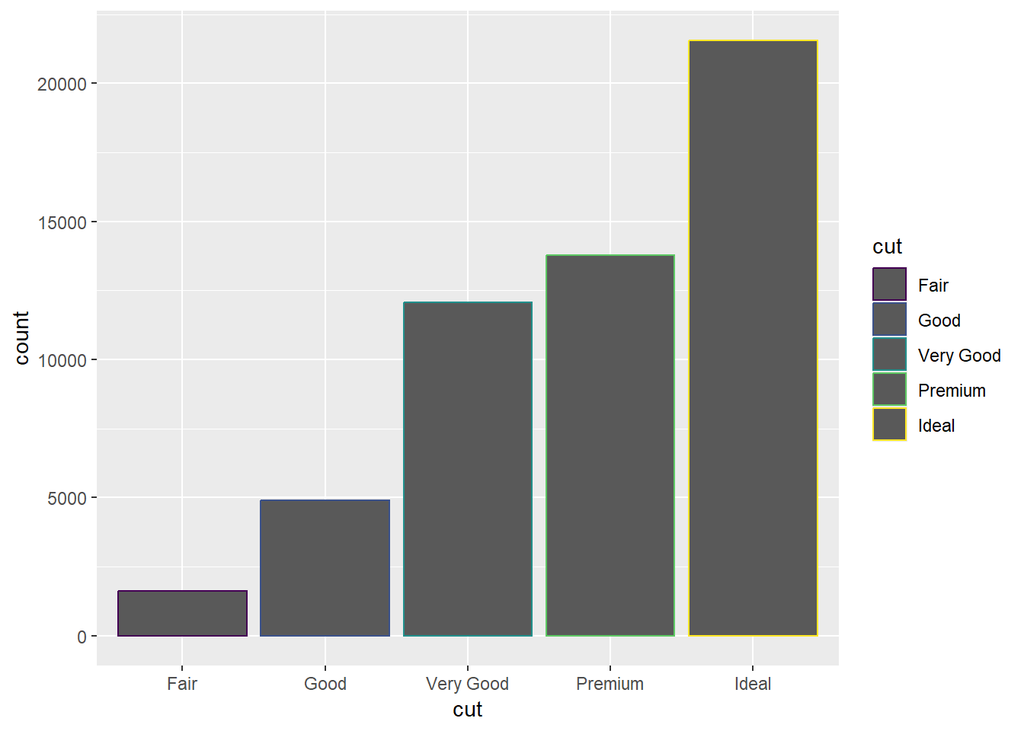

```r
ggplot(data = diamonds) +
  geom_bar(mapping = aes(x = cut, colour = cut))
```

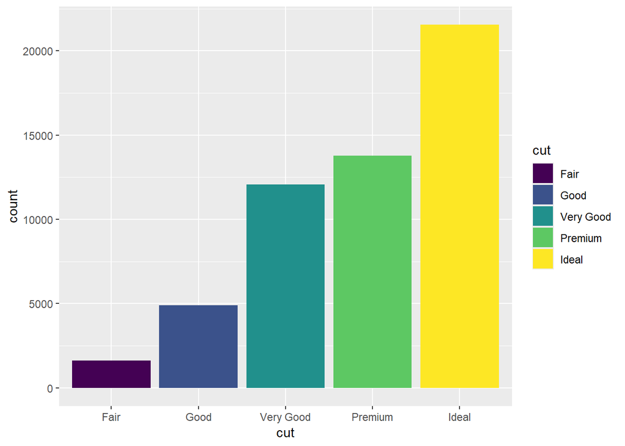

```r
ggplot(data = diamonds) +
  geom_bar(mapping = aes(x = cut, fill = cut))
```

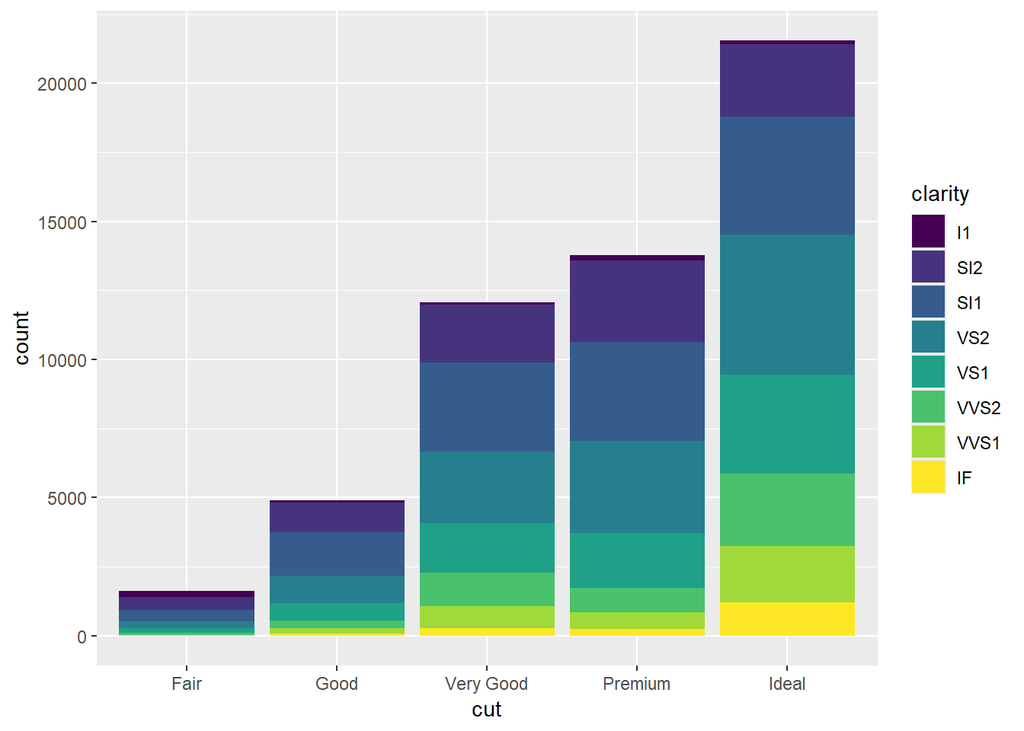

```r
#using "clarity" as the color variable
ggplot(data = diamonds) +
  geom_bar(mapping = aes(x = cut, fill = clarity))
```

Tip: The ability to make position adjustments is vital, it allows you to customize your plots in three ways, identity (raw data), fill (changes heights) and dodge (which forces ggplot2 to not put things on top of each other).

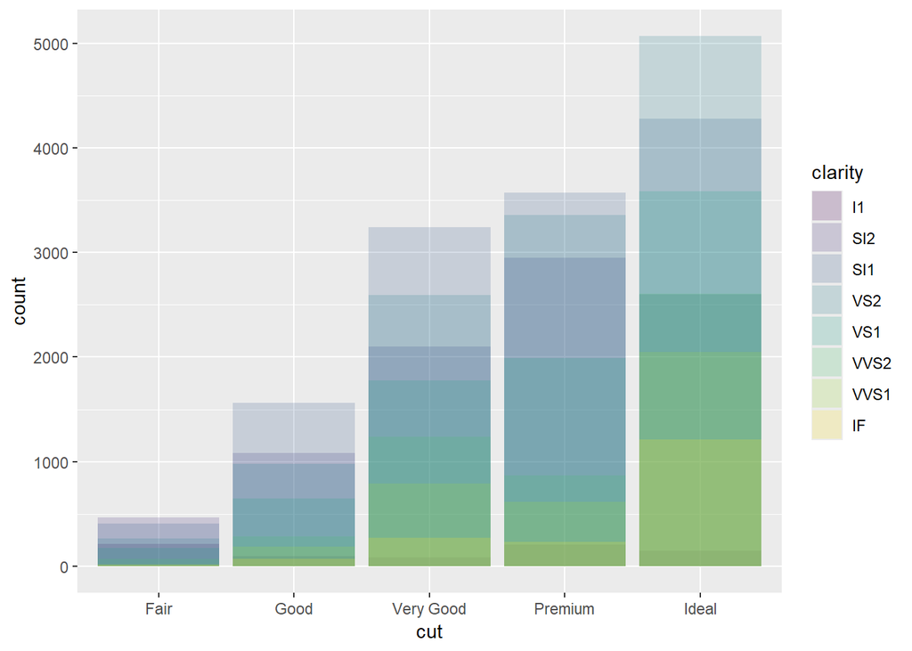

```r
#Using "identity" as position

#To alter transparency (alpha)
ggplot(data = diamonds, mapping = aes(x = cut, fill = clarity)) +
  geom_bar(alpha = 1/5, position = "identity")
```

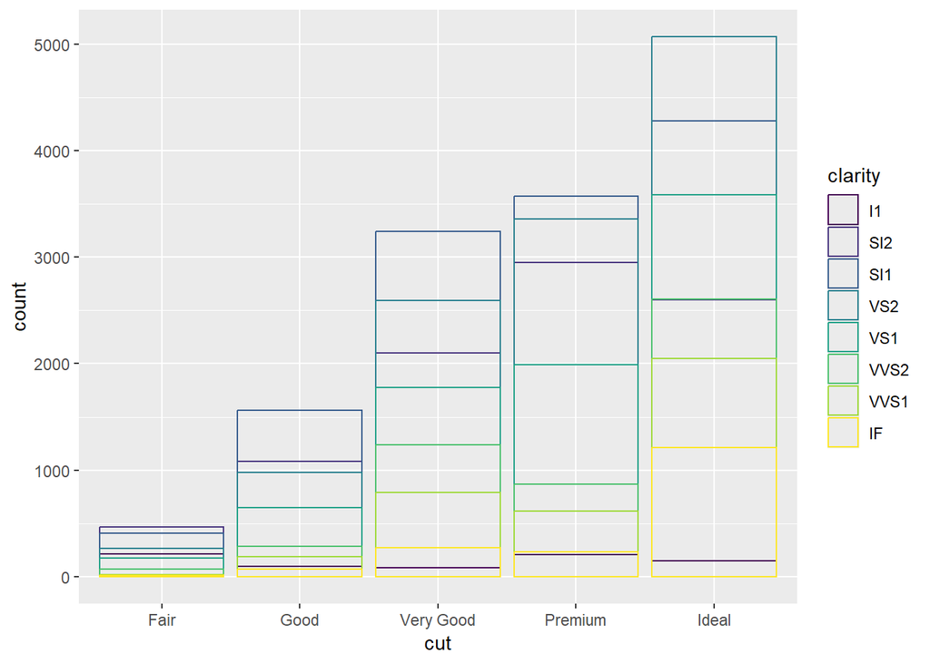

```r
#To color the bar outlines with no fill color
ggplot(data = diamonds, mapping = aes(x = cut, colour = clarity)) +
  geom_bar(fill = NA, position = "identity")
```

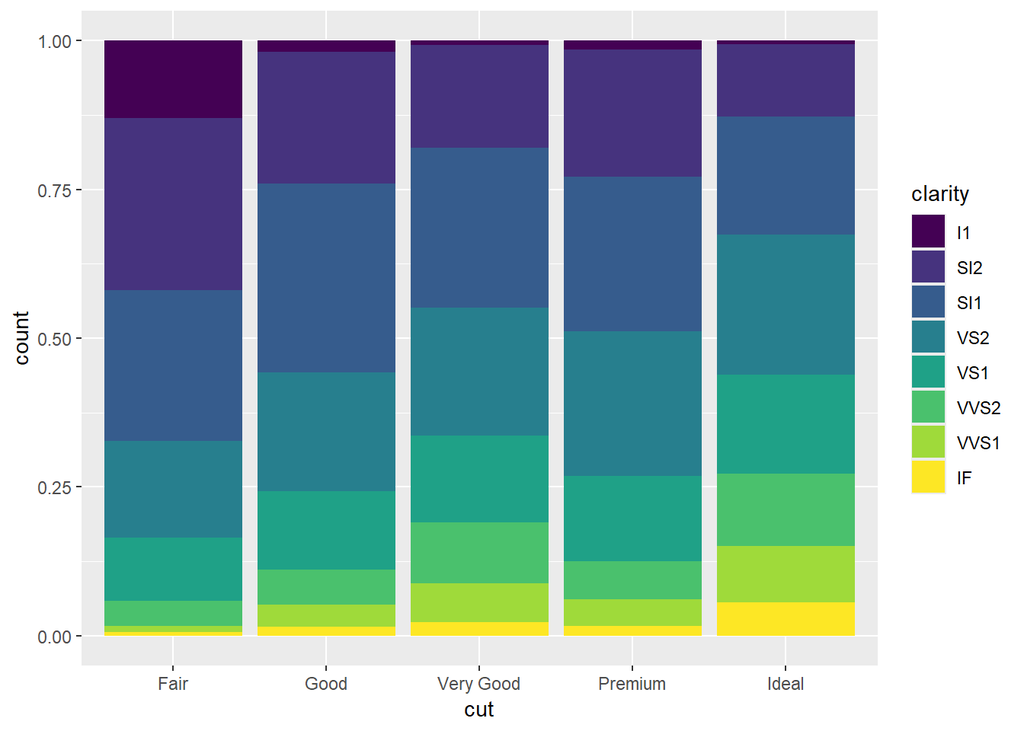

```r
#Using "fill" to stack each sets at the same height
ggplot(data = diamonds) +
  geom_bar(mapping = aes(x = cut, fill = clarity), position = "fill") #this looks like an abundance plot
```

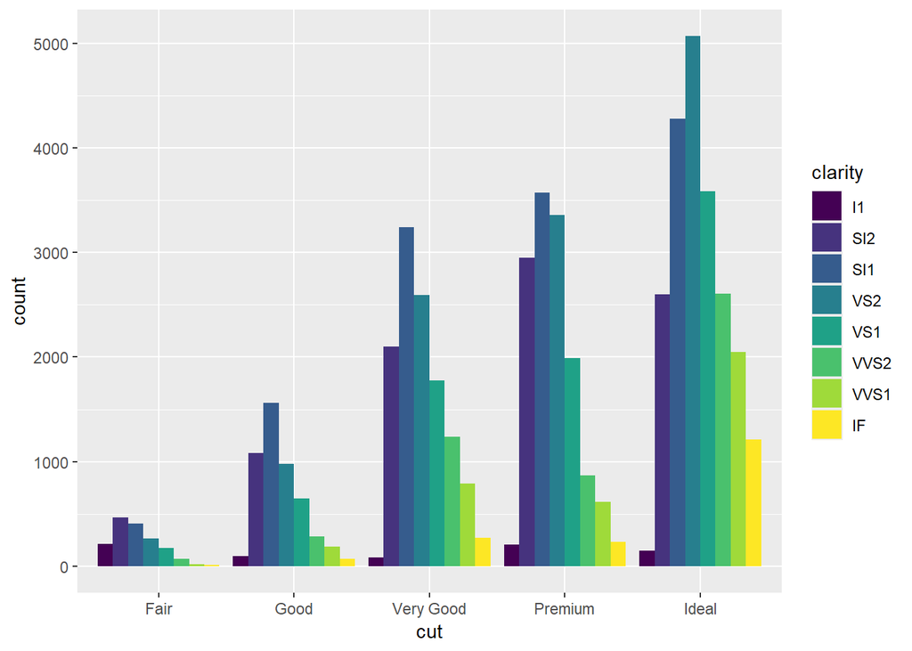

```r
#using "dogde" to place overlapping objects directly beside one another
ggplot(data = diamonds) +
  geom_bar(mapping = aes(x = cut, fill = clarity), position = "dodge")
```

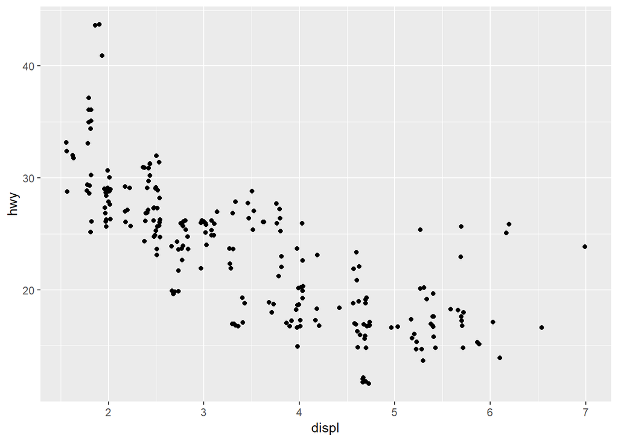

```r
#using "jitter" to avoid overplotting when points overlap, scatterplot > barplots
ggplot(data = mpg) +
  geom_point(mapping = aes(x = displ, y = hwy), position = "jitter")
```

# Layered grammar of graphics

Template for general ggplot2:

```r
#ggplot(data = <DATA>) +
  #<GEOM_FUNCTION>(
     #mapping = aes(<MAPPINGS>),
     #stat = <STAT>,
     #position = <POSITION>
 # ) +
 # <FACET_FUNCTION>
```

[output not shown]

# Workshop 04 Using AI in Programming

```r
#install.packages("ellmer")
#install.packages("chattr")
```

# Testing prompt

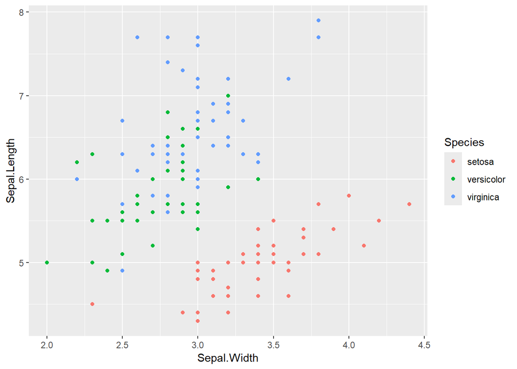

```r
#this was pasted from "Copy to Document" from my Ctrl + Shift + G shortcut
library(ggplot2)

data(iris)

ggplot(iris, aes(x = Sepal.Width, y = Sepal.Length, color = Species)) +
  geom_point()
```

# Conditional Logic - filtering your data

```r
# Simple Example: Checking Sea Surface Temperature (SST)
sst <- 30.2

if (sst > 29.5) {
  print("Warning: Marine heatwave threshold exceeded!")
} else {
  print("SST remains within baseline parameters.")
}
```

```
## [1] "Warning: Marine heatwave threshold exceeded!"
```

```r
# Load tidyverse (if not already loaded)
library(tidyverse)

# Sample coral data
coral_monitoring <- tibble(
  site = c("Site_A", "Site_B", "Site_C"),
  depth_m = c(12, 35, 8)
)

# Classify depth using if_else
coral_monitoring <- coral_monitoring %>%
  mutate(zone = if_else(depth_m > 30, "Deep Reef", "Shallow Reef"))
```

```r
# the mutate() function:
#I used my Gemini shortcut but can also use #?mutate
# The mutate() function, part of the dplyr package within the tidyverse, is used to add new variables to a data frame or to transform existing variables. It always returns a new data frame with the modified or newly created columns, keeping all other columns and rows intact.

#To get more information about mutate(), you can use the help function in R:


#The %>% symbol (pipe operator)
#The %>% symbol is the pipe operator, originating from the magrittr package but widely used and re-exported by dplyr and other tidyverse packages. Its primary purpose is to make code more readable and easier to write when chaining multiple operations together. It takes the output of the expression on its left and passes it as the first argument (by default) to the function on its right. This avoids nested function calls and the need to create intermediate objects.

#To get more information about the %>% operator, you can use the help function in R:
```

```r
coral_monitoring <- coral_monitoring %>%
  mutate(reef_category = case_when(
    depth_m < 10  ~ "Lagoon / Flats",
    depth_m <= 30 ~ "Crest / Slope",
    depth_m > 30  ~ "Mesophotic / Deep",
    TRUE          ~ "Unclassified" # Catch-all remainder
  ))
```

```r
#Task: Environmental Stress Classification
library(dplyr)

marine_stations <- tibble(
  salinity = c(35, 28, 32, 12)
)

marine_stations <- marine_stations %>%
  mutate(
    environment_type = case_when(
      salinity < 15 ~ "Estuarine",
      salinity >= 15 & salinity <= 30 ~ "Brackish",
      salinity > 30 ~ "Marine",
      TRUE ~ NA_character_ # Fallback for any unhandled cases (optional)
    )
  )

marine_stations
```

```
## # A tibble: 4 × 2
##   salinity environment_type
##      <dbl> <chr>
## 1       35 Marine
## 2       28 Brackish
## 3       32 Marine
## 4       12 Estuarine
```

```r
# Base R: for-loops
# Classic loop anatomy
for (year in 2020:2024) {
  print(paste("Processing climate data for year:", year))
}
```

```
## [1] "Processing climate data for year: 2020"
## [1] "Processing climate data for year: 2021"
## [1] "Processing climate data for year: 2022"
## [1] "Processing climate data for year: 2023"
## [1] "Processing climate data for year: 2024"
```

```r
# Loop across index sequences
transect_lengths <- c(50, 100, 25, 75)

for (i in seq_along(transect_lengths)) {
  print(paste("Transect number", i, "measures", transect_lengths[i], "metres."))
}
```

```
## [1] "Transect number 1 measures 50 metres."
## [1] "Transect number 2 measures 100 metres."
## [1] "Transect number 3 measures 25 metres."
## [1] "Transect number 4 measures 75 metres."
```

```r
#  Calculating Square Roots of Site Vectors
#Using a standard for-loop:
site_areas <- c(144, 400, 625)
results <- numeric(length(site_areas)) # Must build an empty container first

for(i in seq_along(site_areas))
  results[i] <- sqrt(site_areas[i])

#Using the purrr equivalent:
library(purrr)
# Map directly and define your expected output type explicitly
mapped_results <- map_dbl(site_areas, sqrt)

# Iterate a summary function over split lists of data
iris %>%
  split(.$Species) %>%
  map(~summary(.x))
```

```
## $setosa
##   Sepal.Length    Sepal.Width     Petal.Length    Petal.Width
##  Min.   :4.300   Min.   :2.300   Min.   :1.000   Min.   :0.100
##  1st Qu.:4.800   1st Qu.:3.200   1st Qu.:1.400   1st Qu.:0.200
##  Median :5.000   Median :3.400   Median :1.500   Median :0.200
##  Mean   :5.006   Mean   :3.428   Mean   :1.462   Mean   :0.246
##  3rd Qu.:5.200   3rd Qu.:3.675   3rd Qu.:1.575   3rd Qu.:0.300
##  Max.   :5.800   Max.   :4.400   Max.   :1.900   Max.   :0.600
##        Species
##  setosa    :50
##  versicolor: 0
##  virginica : 0
##
##
##
##
## $versicolor
##   Sepal.Length    Sepal.Width     Petal.Length   Petal.Width
##  Min.   :4.900   Min.   :2.000   Min.   :3.00   Min.   :1.000
##  1st Qu.:5.600   1st Qu.:2.525   1st Qu.:4.00   1st Qu.:1.200
##  Median :5.900   Median :2.800   Median :4.35   Median :1.300
##  Mean   :5.936   Mean   :2.770   Mean   :4.26   Mean   :1.326
##  3rd Qu.:6.300   3rd Qu.:3.000   3rd Qu.:4.60   3rd Qu.:1.500
##  Max.   :7.000   Max.   :3.400   Max.   :5.10   Max.   :1.800
##        Species
##  setosa    : 0
##  versicolor:50
##  virginica : 0
##
##
##
##
## $virginica
##   Sepal.Length    Sepal.Width     Petal.Length    Petal.Width
##  Min.   :4.900   Min.   :2.200   Min.   :4.500   Min.   :1.400
##  1st Qu.:6.225   1st Qu.:2.800   1st Qu.:5.100   1st Qu.:1.800
##  Median :6.500   Median :3.000   Median :5.550   Median :2.000
##  Mean   :6.588   Mean   :2.974   Mean   :5.552   Mean   :2.026
##  3rd Qu.:6.900   3rd Qu.:3.175   3rd Qu.:5.875   3rd Qu.:2.300
##  Max.   :7.900   Max.   :3.800   Max.   :6.900   Max.   :2.500
##        Species
##  setosa    : 0
##  versicolor: 0
##  virginica :50
##
##
##
```

```r
# comparing using chattr:
library(purrr) # For map_dbl

# Sample list of fish count data
fish_counts_list <- list(
  reef_a = c(10, 15, 12, 18, 20),
  reef_b = c(5, 7, 6, 8, 9),
  reef_c = c(22, 25, 20, 28, 23)
)

# Using a for-loop
mean_counts_for_loop <- numeric(length(fish_counts_list))
for (i in seq_along(fish_counts_list)) {
  mean_counts_for_loop[i] <- mean(fish_counts_list[[i]])
}
mean_counts_for_loop
```

```
## [1] 15.0  7.0 23.6
```

```r
#It is in fact much simpler
```

```r
#Function construction blueprint

# Function Definition
calculate_coral_mortality <- function(initial_count, surviving_count) {

  # Logic safety switch using our conditional tools!
  if (initial_count <= 0) {
    stop("Initial count must be greater than zero.")
  }

  mortality_rate <- (initial_count - surviving_count) / initial_count
  return(mortality_rate)
}

# Utilizing your custom function
calculate_coral_mortality(initial_count = 120, surviving_count = 84)
```

```
## [1] 0.3
```

```r
#Custom function construction task

#convert_temp_c_to_f <- function(celsius_temp) {
  # Absolute zero in Celsius
  #absolute_zero_c <- -273.15

  # Conditional safety check
 # if (celsius_temp < absolute_zero_c) {
  #  stop("Temperature cannot be below absolute zero (-273.15 degrees Celsius).")


  # Perform the conversion
  #fahrenheit_temp <- (celsius_temp * 9/5) + 32

  #return(fahrenheit_temp)
```

```r
# Test with a valid temperature (e.g., 25 degrees Celsius)
#valid_celsius <- 25
#convert_temp_c_to_f(valid_celsius)
# Test with an invalid temperature (e.g., -300 degrees Celsius)
# This will stop execution and print the error message
#invalid_celsius <- -300
#convert_temp_c_to_f(invalid_celsius)

#The error code does appear!
```

[output not shown]

```r
# kniting for blogging
library(knitr, markdown)
#knit("Workshop.Rmd") # produces a .md file (use name of your markdown file)
#markdown::html_format("Workshop.md", "workshop.html") # produces clean .html
#rmarkdown::render("workshop.Rmd")
```